# Google Data Analytics Capstone: Cyclistic

## **10.5g Average Speed During Optimal Weather**

#### Station-to-station activity will be reviewed in detail later, but this data can be used now to make broad observations about the average speed of casual and member riders when using classic and electric bikes.

#### The commands below calculate the distance between start and end stations for each ride taking place from May to October (when weather conditions are least likely to impact speed/rider comfort) and then uses average trip length to establish miles-per-hour.

#### **Note** that the “distHaversine” command assumes no obstacles or pauses for traffic signals, and thus can only be used to determine the relative speed of each customer/bike combination. Additionally, trips that start and end at the same station are not used for this study, as there is no observable distance to calculate.

```r
may_to_october_behavior <- trips_w_stations %>%
  filter(month == 'May'|
           month == 'June'|
           month == 'July'|
           month == 'August'|
           month == 'September'|
           month == 'October') %>%
  rowwise() %>%
  mutate(trip_distance = distHaversine(c(start_lng, start_lat), c(end_lng, end_lat),
                                       r=6378137)) %>%
  filter(trip_distance > 0) %>%
  group_by(customer_type, bike_type) %>%
  summarize(mean_trip_length = mean(trip_length),
            mean_distance_travelled_m = mean(trip_distance),
            ride_count = n_distinct(ride_id)) %>%
  mutate(avg_mph = (mean_distance_travelled_m/mean_trip_length)*2.2369)
```

## **10.5g Visualizing Average Speed During Optimal Weather**

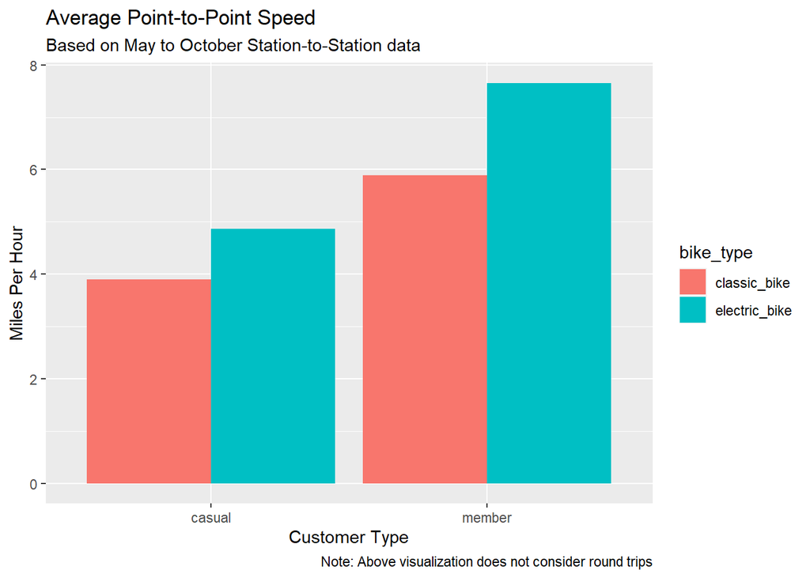

```r
viz_customer_speed <- ggplot(data = may_to_october_behavior)+
  geom_col(mapping = aes(x = customer_type,
                         y = avg_mph,
                         fill = bike_type),
           position = 'dodge')+
  labs(title = "Average Point-to-Point Speed",
       subtitle = "Based on May to October Station-to-Station data",
       x = "Customer Type",
       y = "Miles Per Hour",
       caption = "Note: Above visualization does not consider round trips")
print(viz_customer_speed)
```

## **10.5g Interpreting Average Speed**

#### Casual customers on electric bikes move 24.66% faster than those using classic bikes, while members see a 30.07% increase in the same scenario.

#### Members on classic bikes move 50.93% faster than casual customers on classic bikes, and move 57.47% faster than casual customers when both are using electric bikes.

#### These findings suggest two possibilities: this can reinforce the theory that members are generally more adept cyclists than casual riders, or it could suggest different use cases between rider types.

#### Point-to-point member rides for purely transportation purposes are likely to be faster and more direct, compared to casual recreational rides that may take less optimal paths to reach their destination.

## **10.5h Implications of Casual/Member Behavior**

#### The large change in trip duration for casual riders switching from classic to electric bikes, combined with their lower average travel speed, preference for electric bikes, and previously-shown sensitivity to poor weather suggest casual riders are generally less experienced cyclists than members.

#### This demonstrable difference in skill and/or experience is a key takeaway we will share with our marketing team, as they can craft the campaign to approach novice cyclists

## **10.6 Understanding Peak Season Behavior**

## **10.6a Comparing Rider Behavior During Weekends and Rush Hour**

#### While we have a good grasp of the basic differences between casual and member riders, we now need to apply our behavioral analysis to three key times in the week highlighted in section 10.2: weekend rides, which are most popular amongst casual riders, and am/pm commutes, which appear to be the most common use case for member riders.

#### By understanding the behavior of customers during this time, we can better understand how to bridge the gap between customer types and convert casual riders into members.

#### To make our analysis more meaningful to the business task, the following analysis will drop annual ride data and instead focus on calendar weeks 24 through 27.

```r
#### Seperating weekend/workday rides into distinct dataframes from peak_season_trips
peak_season_weekend <- peak_season_trips %>%
  filter(workday_weekend == 'weekend')

peak_season_workday <- peak_season_trips %>%
  filter(workday_weekend == 'workday')
```

#### With these peak weeks isolated, I will now group by bike type, customer type, and start hour.

```r
## Workday
peak_season_workday_grouped <- peak_season_workday %>%
  group_by(customer_type, start_hour, bike_type) %>%
  summarize(mean_trip_duration = mean(trip_length),
            ride_count = n_distinct(ride_id)) %>%
  mutate(percent_of_rides = ((ride_count/sum(ride_count))*100)
  )

## Weekend
peak_season_weekend_grouped <- peak_season_weekend %>%
  group_by(customer_type, start_hour, bike_type) %>%
  summarize(mean_trip_duration = mean(trip_length),
            ride_count = n_distinct(ride_id)) %>%
  mutate(percent_of_rides = ((ride_count/sum(ride_count))*100)
  )
## AM Rush Hour Detail
peak_season_workday_grouped_am_commute <- peak_season_workday %>%
  filter(start_hour >= 7 & start_hour <= 10) %>%
  group_by(customer_type, start_hour, bike_type) %>%
  summarize(mean_trip_duration = mean(trip_length),
            ride_count = n_distinct(ride_id)) %>%
  mutate(percent_of_rides = ((ride_count/sum(ride_count))*100)
  )
## PM Rush Hour Detail
peak_season_workday_grouped_pm_commute <- peak_season_workday %>%
  filter(start_hour >= 16 & start_hour <= 19) %>%
  group_by(customer_type, start_hour, bike_type) %>%
  summarize(mean_trip_duration = mean(trip_length),
            ride_count = n_distinct(ride_id)) %>%
  mutate(percent_of_rides = ((ride_count/sum(ride_count))*100)
  )
```

## **10.6b Peak Season Workday Start Times Vs Annual Workday Start Times**

#### We selected calendar weeks 24 through 27 as our peak season due to the increased percentage of casual riders using the Cyclistic system. The following visualization presents workday start times for casual and member riders for comparison against annual start times established in section 10.2.

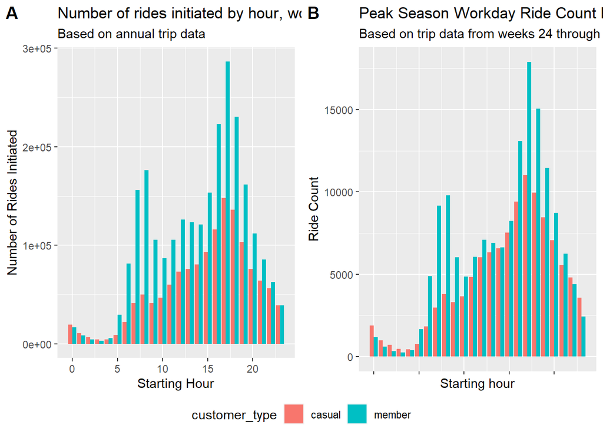

```r
viz_peak_season_workday_start_hour <- ggplot(data = peak_season_workday_grouped)+
  geom_col(mapping = aes(x = start_hour,
                         y = ride_count,
                         fill = customer_type),
           position = 'dodge')+
    labs(title = "Peak Season Workday Ride Count by Starting Hour",
       subtitle = "Based on trip data from weeks 24 through 27",
       x = "Starting hour",
       y = "Ride Count")

print(ggarrange(viz_starting_hour_workday,
                viz_peak_season_workday_start_hour +
                  rremove("x.text"),
          labels = c('A', 'B'),
          common.legend = TRUE, legend = "bottom"))
```

## **10.6b Comparing Peak Season and Annual Workday Start Hours**

#### The above visualization allow us to calculate two key observations:

#### 1) The percentage of casual rides initiated by hour compared to members (referred to below as “**customer split**.”)

#### 2) The proportion of casual rides initiated by hour as a percentage of total casual rides during the workday (referred to below as “**daily split**.”)

#### Note: The following spreadsheet was used to calculate our findings:

#### [View calculations here](https://docs.google.com/spreadsheets/d/15j3CX27zZo-HdaUXQkPM4NaWsqQzzYZOsoB3XdXXxls/edit?usp=sharing)

## **7am to 10:59am:**

#### **Customer Split**: Casual riders make up 32.22% of the system’s rides during this period, compared to an annual average of 25.52% for the same period of time during weekdays.

#### **Daily Split**: This period of time only accounts for 11.93% of all weekday casual rides in peak season, compared to the annual average of 13.03%.

## **11am to 3:59pm:**

#### **Customer Split**: Casual riders make up 47.31% of the system’s rides during this period, compared to the annual average of 37.82%.

#### **Daily Split**: This period accounts for 27.43% of all weekday casual rides, compared to an annual average of 27.76%, indicating no major change in behavior.

## **4pm to 7:59pm:**

#### **Customer Split**: Casual riders make up 43.73% of the system’s rides during this time period, compared to an annual average of 35.84%.

#### **Daily Split**: This period accounts for 35.74% of all weekday casual rides, compared to an annual average of 36.50%.

## **8pm to 11:59pm:**

#### **Customer Split**: Casual riders make up 51.09% of the system’s rides during this time period, compared to an annual average of 44.05%.

#### **Daily Split**: This period accounts for 19.43% of all weekday casual rides, compared to an annual average of 17.10%

## **Midnight to 6:59am:**

#### **Customer Split**: Casual riders initiate 41.04% of the system’s rides during this time period, compared to an annual average of 33.98.05%.

#### **Daily Split**: This time frame accounts for 5.48% of all casual rides taken daily during peak season, compared to an annual average of 5.60%

## **10.6c Comparing Peak Season and Annual Weekend Start Hours**

#### Weekends are a lower priority for this study, but should be observed for any notable changes in behavior before advancing.

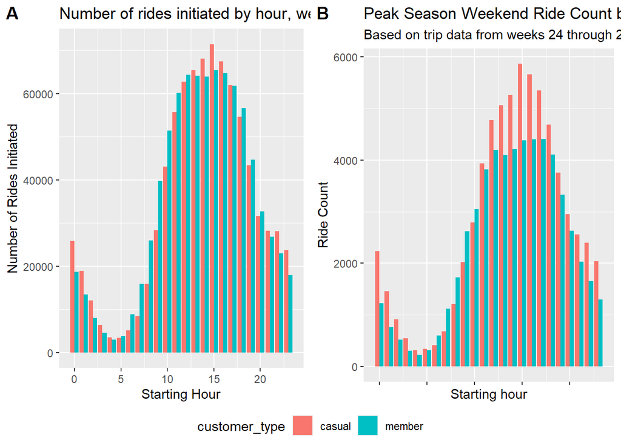

```r
viz_peak_season_weekend_start_hour <- ggplot(data = peak_season_weekend_grouped)+
  geom_col(mapping = aes(x = start_hour,
                         y = ride_count,
                         fill = customer_type),
           position = 'dodge')+
  labs(title = "Peak Season Weekend Ride Count by Starting Hour",
       subtitle = "Based on trip data from weeks 24 through 27",
       x = "Starting hour",
       y = "Ride Count")

print(ggarrange(viz_starting_hour_weekend,
                viz_peak_season_weekend_start_hour +
                  rremove("x.text"),
          labels = c('A', 'B'),
          common.legend = TRUE, legend = "bottom"))
```

## **10.6c Comparing Peak Season Weekends to Annual Weekend Averages**

#### [View calculations here](https://docs.google.com/spreadsheets/d/1n-NvxlH4g2wQRDejBgVTpgTIb12vZje4nmEIprN24LM/edit?usp=sharing)

#### First, We see a marked increase in casual riders as a percentage of overall rides by hour. During peak season, hourly casual ridership increases by 5.33% compared to the annual average.

#### This is a smaller increase in casual ridership than we see during peak season workdays, but that bodes well, as the workday commute use-case appears to be Cyclistic’s best avenue for converting casual riders into members.

#### Second, we see that casual ride counts exceeds member ride counts at almost every hour during peak season weekends.

#### During peak season weekends, members only make up a majority of rides from 5am through 9am. When looking at annual ride counts, members typically make up the majority of weekend rides from 5am through 12pm as well as from 6pm through 8pm. These two periods of high member ridership suggest weekend commuting behavior.

## **10.6d Interpreting Peak-to-Annual Findings**

#### **These findings show that casual customers are more open to midday and early evening (pm commute) rides during peak season. As a result, we will need to create a digital marketing campaign that capitalizes on this trend and in turn encourages casual ridership the morning after an evening Cyclistic ride.**

## **10.6e Finding Optimal Workdays**

## **AM Commutes (7am - 10:59am)**

#### Digital marketing campaigns rely heavily on timing to meet their objectives. As a result, I created a dataframe and visualization to inspect ride counts during peak-season AM and PM commutes.

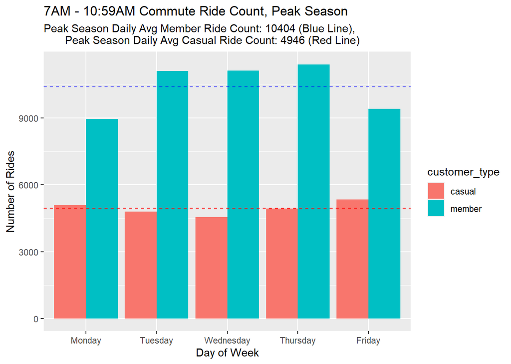

```r
##AM Commute Details
peak_season_workday_am_commute_by_day <- peak_season_workday %>%
  filter(start_hour >= 7 & start_hour <= 10) %>%
  group_by(customer_type, weekday) %>%
  summarize(mean_trip_duration = mean(trip_length),
            ride_count = n_distinct(ride_id))



viz_am_trips_by_weekday <- ggplot(data = peak_season_workday_am_commute_by_day)+
  geom_col(mapping = aes(x = weekday,
                         y = ride_count,
                         fill = customer_type),
           position = 'dodge')+
  labs(title = "7AM - 10:59AM Commute Ride Count, Peak Season",
       subtitle = "Peak Season Daily Avg Member Ride Count: 10404 (Blue Line),
       Peak Season Daily Avg Casual Ride Count: 4946 (Red Line)",
       x = "Day of Week",
       y = "Number of Rides",
  )+
   geom_hline(yintercept= 10404, linetype="dashed", color = "blue")+
  geom_hline(yintercept= 4946, linetype="dashed", color = "red")

print(viz_am_trips_by_weekday)
```

#### [View AM calculations here](https://docs.google.com/spreadsheets/d/17YaY4-D6nbjZYBwQd_-fZJuNd4zPcQ7dCdJKd_xnPmY/edit?usp=sharing)

## **AM Commutes (7am - 10:59am)**

#### Casual customers initiate an average of 4946 rides a day during this period.

#### Friday mornings are most popular (7.94% above average), followed by Monday (2.98% above average), and Thursday (0.27% below average).

#### Members initiate an average of 10404 rides during this period.

#### Thursday mornings are most popular (9.67% above average), followed by Wednesday (6.98% above average), and Tuesday (6.74% above average)

#### Monday mornings are least popular among members (13.89% below average) and Wednesday mornings are least popular among casual riders (7.79% below average.)

## **PM Commutes (4pm - 7:59pm)**

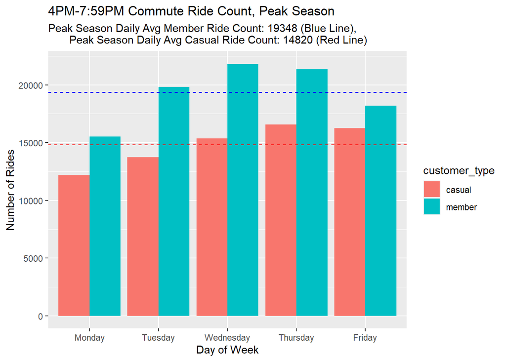

```r
##PM Commute Details
peak_season_workday_pm_commute_by_day <- peak_season_workday %>%
  filter(start_hour >= 16 & start_hour <= 19) %>%
  group_by(customer_type, weekday) %>%
  summarize(mean_trip_duration = mean(trip_length),
            ride_count = n_distinct(ride_id))



viz_pm_trips_by_weekday <- ggplot(data = peak_season_workday_pm_commute_by_day)+
  geom_col(mapping = aes(x = weekday,
                         y = ride_count,
                         fill = customer_type),
           position = 'dodge')+
  labs(title = "4PM-7:59PM Commute Ride Count, Peak Season",
       subtitle = "Peak Season Daily Avg Member Ride Count: 19348 (Blue Line),
       Peak Season Daily Avg Casual Ride Count: 14820 (Red Line)",
       x = "Day of Week",
       y = "Number of Rides",
  )+
   geom_hline(yintercept= 19348, linetype="dashed", color = "blue")+
  geom_hline(yintercept= 14820, linetype="dashed", color = "red")

print(viz_pm_trips_by_weekday)
```

#### [View PM Calculations here] (https://docs.google.com/spreadsheets/d/1jeHPeFHj-CDCpMT-jTYfpbKqKHBdYsWsAITMRoXfR0A/edit?usp=sharing)

## **PM Commutes (4pm - 7:59pm)**

#### Casual customers initiate a daily average of 14820 rides during this period.

#### Thursday nights are most popular (11.72% above average), followed by Friday nights (9.69% above average), and Wednesday nights (3.60% above average.)

#### Members initiate an average of 19348 rides during this period.

#### Wednesday nights are most popular (12.80% above average), followed by Thursday nights (10.45% above average), and Tuesday nights (2.41% above average.)

## **10.6e Interpreting Peak Workday Commuter Habits**

#### Subscription services like Cyclistic depend on creating repeat behavior, where using the service becomes a habit.

#### To that end, the visualizations presents a possible promotion concept: offering casual customers who use Cyclistic on Thursday evenings a free pass for a ride on Friday morning.

#### This strategy encourages repeat behavior from Thursday night into Friday morning, encouraging repeat use in a short span of time to artificially create a pattern of repeat use. Further, this will encourage casual ridership during the AM commute period, where we see the least casual ridership growth during peak season.

## **10.7 Comparing Casual and Member Trip Durations During Peak Season**

#### Before looking at station-to-station data, we will review trip durations during the peak season weekday AM commute period (7am - 10:59) and the peak season weekday PM commute period (4pm - 7:59pm.) This review may give us better insights into how casual and member riders use the system during these key time periods.

## **10.7a Baseline Trip Duration (AM)**

#### The following dataframe provides baseline trip durations for the AM commute period we will compare against peak season.

```r
## AM Baseline
annual_workday_duration_am <- trips_workday %>%
filter(start_hour >= 7 & start_hour <= 10) %>%
  group_by(customer_type, bike_type) %>%
  summarize(mean_duration = mean(trip_length))
view(annual_workday_duration_am)
```

## **10.7a Baseline Trip Duration (AM)**

#### Casual riders have a baseline trip duration of 20 minutes and 56 seconds (1256 seconds) on classic bikes and a baseline trip duration of 14 minutes and 38 seconds (878 seconds) on electric bikes.

#### Casual electric rides are on average 30.13% shorter than casual classic bike rides.

#### Members have a baseline trip duration of 12 minutes (720 seconds) on classic bikes, and a baseline trip duration of 10 minutes and 44 seconds (644 seconds) on electric bikes.

#### Member electric rides are on average 10.65% shorter than member classic bike rides.

## **10.7b Peak Season AM Commute Duration**

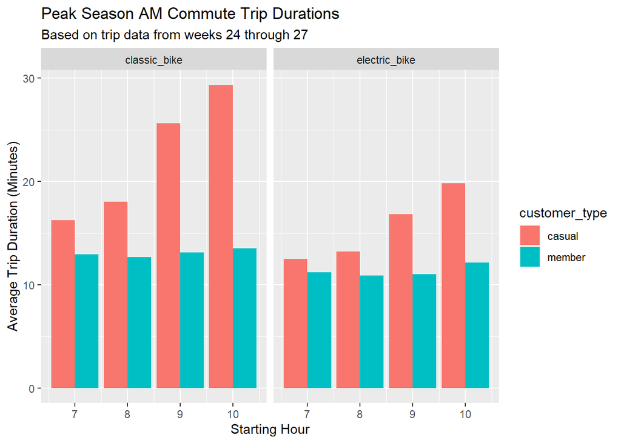

```r
viz_peak_season_workday_duration_am <- ggplot(data = peak_season_workday_grouped_am_commute)+
  geom_col(mapping = aes(x = start_hour,
                         y = (mean_trip_duration/60),
                         fill = customer_type),
           position = 'dodge')+
  facet_wrap(~bike_type)+
  labs(title = "Peak Season AM Commute Trip Durations",
       subtitle = "Based on trip data from weeks 24 through 27",
       x = "Starting Hour",
       y = "Average Trip Duration (Minutes)")

print(viz_peak_season_workday_duration_am)
```

## **10.7b Peak Season AM Commute Duration**

#### The above visualization shows consistent ride durations for members throughout the AM period, regardless of bike type or start hour.

#### Casual riders show significantly longer riders from 9am through 10:59am, regardless of bike type.

## **10.7c Inspecting AM Classic Casual Classic Trip Duration Variance**

#### The change in casual ride duration after 9am is notable. The following filtered dataframes and visualizations display the variance in trip duration from annual AM averages.

```r
classic_casual_workday_am_peak <- peak_season_workday %>%
  filter(customer_type == 'casual' & bike_type == 'classic_bike') %>%
  filter(start_hour >= 7 & start_hour <= 10) %>%
  group_by(start_hour) %>%
  summarize(mean_trip_duration = mean(trip_length)) %>%
  mutate(percent_variance = ((mean_trip_duration - 1256.3647)/1256.3647)*100)
```

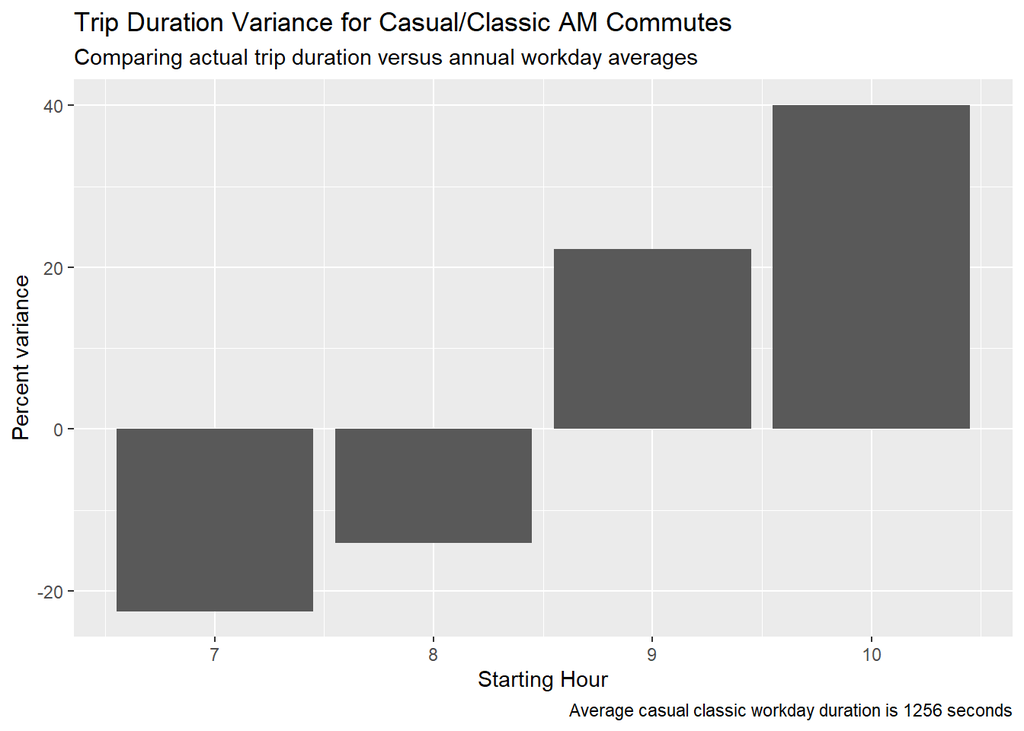

```r
viz_am_casual_classic_variance <- ggplot(data = classic_casual_workday_am_peak)+
  geom_col(mapping = aes(x = start_hour,
                         y = percent_variance
  ))+
  labs(title = 'Trip Duration Variance for Casual/Classic AM Commutes',
       subtitle = 'Comparing actual trip duration versus annual workday averages',
       x = 'Starting Hour',
       y = 'Percent variance',
       caption = 'Average casual classic workday duration is 1256 seconds')

print(viz_am_casual_classic_variance)
```